# Indel Signature InsDel_F

# InsDel_F

**Note**

InsDel_F and ID_F are primarily characterized by 2bp deletions arising from short tandem repeats in which the deleted sequence is repeated 1 to 3 times, or from deletions associated with 1bp microhomology. Previous studies have shown that this mutational process depends on TOP1‑mediated cleavage at genome‑embedded ribonucleotides under conditions of RNase H2 deficiency, and has been validated in yeast, human cell lines, and mouse models (Reijns et al., Nature, 2022). In contrast to ID4/C_ID4, which exhibits a broader spectrum of 2–5bp deletions at short tandem repeats, ID_F and InsDel_F are specifically dominated by 2bp deletions and show a strong preference for mutations occurring at CTCT motifs, whereas C_ID4 is preferentially associated with TTTT motifs.

(corresponds to 83-type signature ID_F )

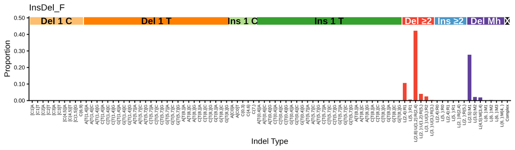

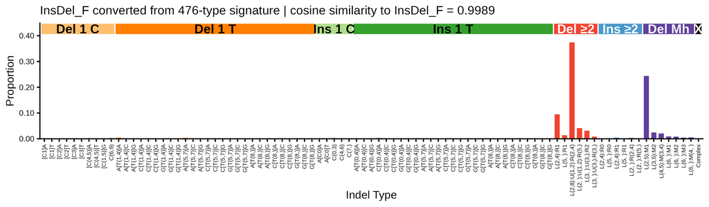

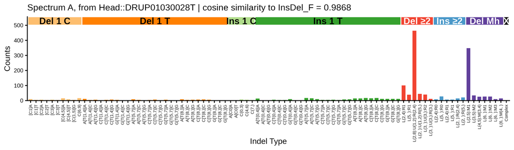

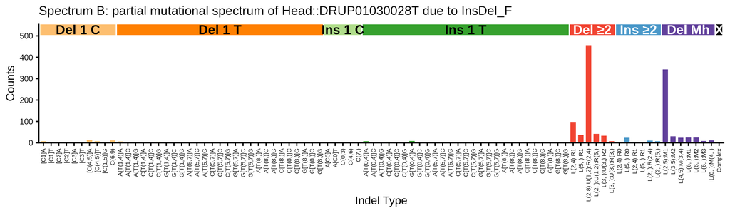

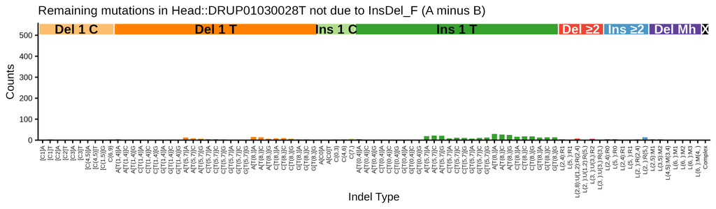

## 476-type representations corresponding to InsDel_F

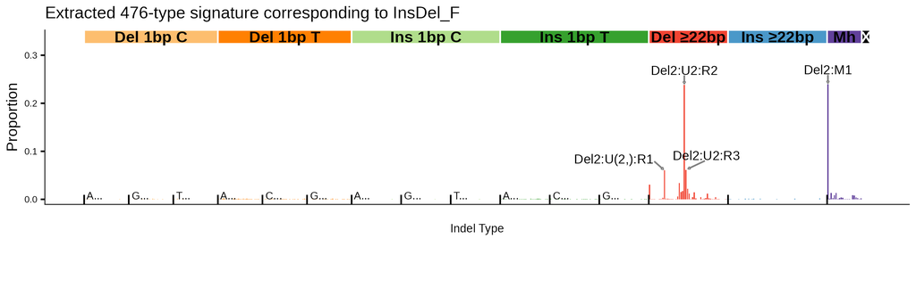

476-type spectrum of the supporting tumor Head::DRUP01030028T; cosine similarity to the extracted 476-type signature is 0.9866

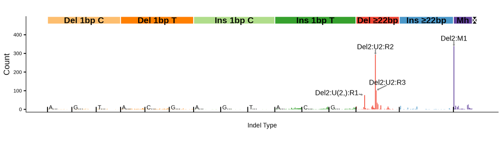

## 83-type signature corresponding to InsDel_F ( ID_F )

**Click here to show 83-type plots**

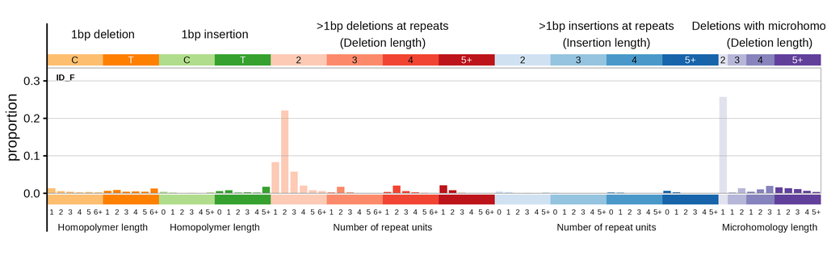

83-type signature converted from 476-type signature corresponding to InsDel_F | cosine similarity to ID_F: 0.9952

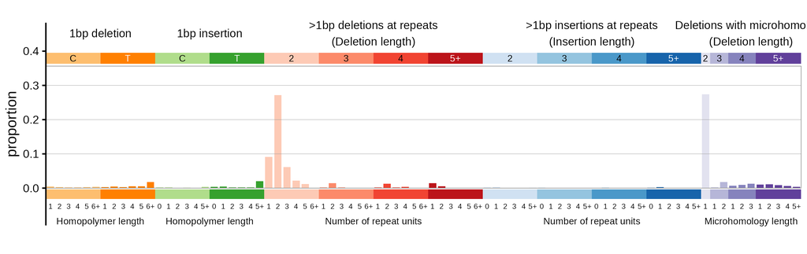

83-type spectrum of the supporting tumor Head::DRUP01030028T | cosine similarly to ID_F: 0.9361

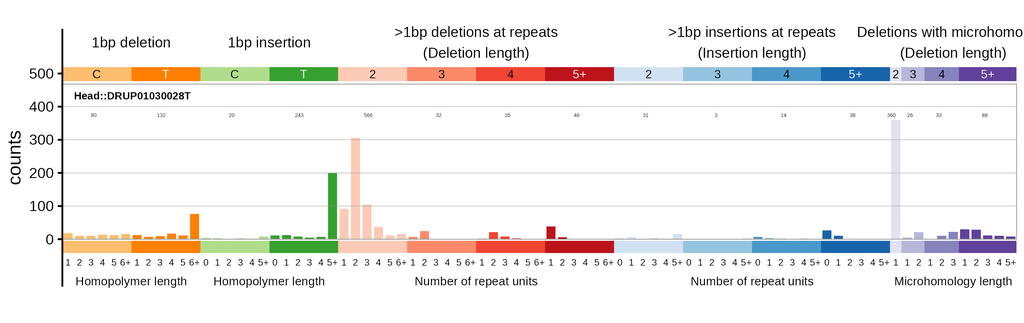

### Similar COSMIC signatures

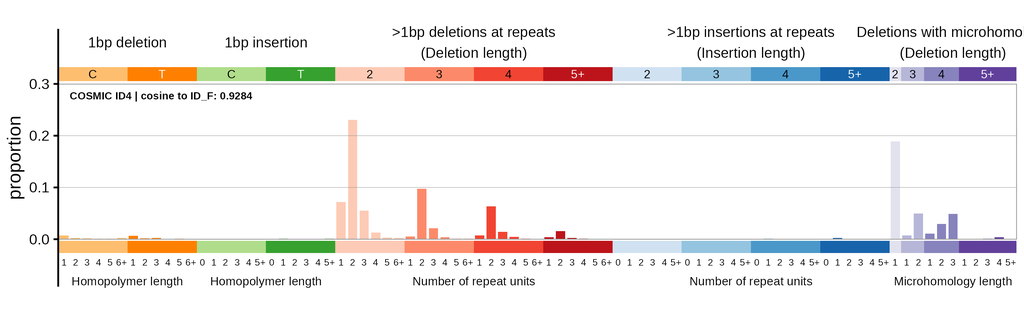

### Similar signatures from Jin et al. 2024

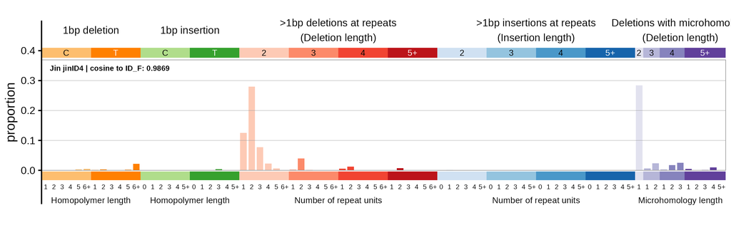